# InfHresExpDH

I. Hanka

2025-10-24

## load object

```r
fileNam <- "/Users/immbio/Desktop/HumanHeartCarTrans2/data/Human_heart_ExpDH.rds"
seuratExpDH <- readRDS(fileNam)
```

```r
seuratExpDH$clusterName <- "clusterName"
seuratExpDH$clusterName[which(seuratExpDH$RNA_snn_res.0.4 %in% "0" )] <- "Fb1"
seuratExpDH$clusterName[which(seuratExpDH$RNA_snn_res.0.4 %in% "1" )] <- "PerivFb"
seuratExpDH$clusterName[which(seuratExpDH$RNA_snn_res.0.4 %in% "2" )] <- "Mph2"
seuratExpDH$clusterName[which(seuratExpDH$RNA_snn_res.0.4 %in% "3" )] <- "BEC1"
seuratExpDH$clusterName[which(seuratExpDH$RNA_snn_res.0.4 %in% "4" )] <- "Fb2"
seuratExpDH$clusterName[which(seuratExpDH$RNA_snn_res.0.4 %in% "5" )] <- "CM"
seuratExpDH$clusterName[which(seuratExpDH$RNA_snn_res.0.4 %in% "6" )] <- "Tcell"
seuratExpDH$clusterName[which(seuratExpDH$RNA_snn_res.0.4 %in% "7" )] <- "BEC2"
seuratExpDH$clusterName[which(seuratExpDH$RNA_snn_res.0.4 %in% "8" )] <- "VSMC"
seuratExpDH$clusterName[which(seuratExpDH$RNA_snn_res.0.4 %in% "9" )] <- "Mph1"
seuratExpDH$clusterName[which(seuratExpDH$RNA_snn_res.0.4 %in% "10" )] <- "BEC3"
seuratExpDH$clusterName[which(seuratExpDH$RNA_snn_res.0.4 %in% "11" )] <- "NC"
seuratExpDH$clusterName[which(seuratExpDH$RNA_snn_res.0.4 %in% "12" )] <- "BaroRec"
seuratExpDH$clusterName[which(seuratExpDH$RNA_snn_res.0.4 %in% "13" )] <- "Bcell"
seuratExpDH$clusterName[which(seuratExpDH$RNA_snn_res.0.4 %in% "16" )] <- "LEC"
seuratExpDH$clusterName[which(seuratExpDH$RNA_snn_res.0.4 %in% "18" )] <- "Adipoc"

colclusterName <- c("#67001f", "#f4a582","#D53E4F", "#003c30", "#66C2A5", "#BEAEF8","#BEAED4", "#c7eae5", "#B09C85", "#4e5a4c","#393A3F","pink","#4588CA","#3299CA","#FCC80B","#628395")
names(colclusterName) <- c("CM","Fb1","Fb2","PerivFb","VSMC","BEC1","BEC2","BEC3","LEC","NC","BaroRec","Adipoc","Mph1","Mph2","Tcell", "Bcell")

coldiseaseCond <- c("#dfc27d","#BE3144","#f4a582","#B45B5C","#8c510a","#202547","#355C7D","#779d8d", "#01665e", "#3288BD", "#BEAED4")
names(coldiseaseCond) <- c("donorheart", "explant", "visit1", "visit2", "visit3", "visit4", "visit5", "visitX1", "visitX2", "visitX3", "visitX4")

# Combine slots
seuratExpDH$patient_diseaseCond <- paste0(seuratExpDH$patient, '_', seuratExpDH$diseaseCond)
#table(seuratExpDH$patient_diseaseCond)

seuratExpDH$patient_clusterName <- paste0(seuratExpDH$patient, '_', seuratExpDH$clusterName)
#table(seuratExpDH$patient_clusterName)

seuratExpDH$diseaseCond_clusterName <- paste0(seuratExpDH$diseaseCond, '_', seuratExpDH$clusterName)
#table(seuratExpDH$diseaseCond_clusterName)
```

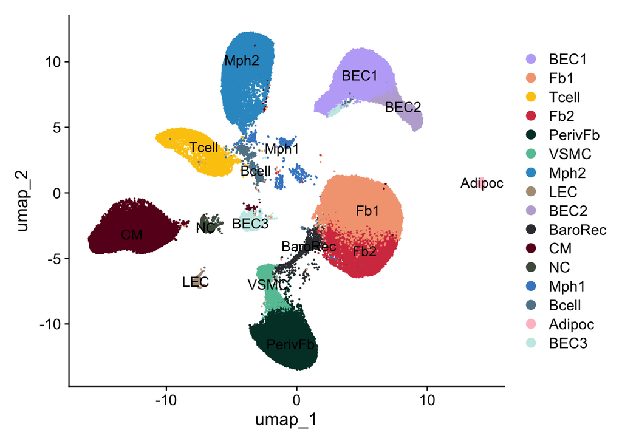

```r
Idents(seuratExpDH) <- seuratExpDH$clusterName
DimPlot(seuratExpDH, reduction = "umap", cols = colclusterName, raster = FALSE, label= TRUE)
```

## subset for all infectious clusters (Inf)

```r
## subset inflammatory cells
idents <- seuratExpDH$clusterName
seuratInfExpDH <- subset(seuratExpDH, idents = c ("Mph1", "Mph2", "Tcell", "Bcell"))
levels(seuratInfExpDH)
```

```
## [1] "Tcell" "Mph2"  "Mph1"  "Bcell"
```

```r
table(seuratInfExpDH$orig.ident)
```

```
##
##
## 21643
```

```r
table(seuratInfExpDH$clusterName)
```

```
##
## Bcell  Mph1  Mph2 Tcell
##   995   494 15418  4736
```

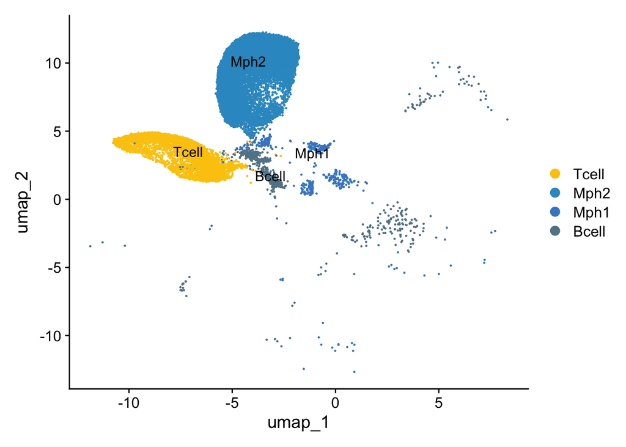

```r
DimPlot(seuratInfExpDH, reduction = "umap", cols = colclusterName, label=TRUE)
```

# Rerun seurat object Inf

```r
# rerun seurat
seuratInfExpDH <- NormalizeData (object = seuratInfExpDH)
seuratInfExpDH <- FindVariableFeatures(object = seuratInfExpDH)
seuratInfExpDH <- ScaleData(object = seuratInfExpDH, verbose = TRUE)
seuratInfExpDH <- RunPCA(object=seuratInfExpDH, npcs = 30, verbose = FALSE)
seuratInfExpDH <- RunTSNE(object=seuratInfExpDH, reduction="pca", dims = 1:20)
seuratInfExpDH <- RunUMAP(object=seuratInfExpDH, reduction="pca", dims = 1:20)
seuratInfExpDH <- FindNeighbors(object = seuratInfExpDH, reduction = "pca", dims= 1:20)

res <- c(0.1, 0.25, 0.4, 0.6, 0.8)
for (i in 1:length(res)) {
  seuratInfExpDH <- FindClusters(object = seuratInfExpDH, resolution = res[i], random.seed = 1234)
}
```

```
## Modularity Optimizer version 1.3.0 by Ludo Waltman and Nees Jan van Eck
##
## Number of nodes: 21643
## Number of edges: 704619
##
## Running Louvain algorithm...
## Maximum modularity in 10 random starts: 0.9511
## Number of communities: 6
## Elapsed time: 2 seconds
## Modularity Optimizer version 1.3.0 by Ludo Waltman and Nees Jan van Eck
##
## Number of nodes: 21643
## Number of edges: 704619
##
## Running Louvain algorithm...
## Maximum modularity in 10 random starts: 0.9186
## Number of communities: 12
## Elapsed time: 2 seconds
## Modularity Optimizer version 1.3.0 by Ludo Waltman and Nees Jan van Eck
##
## Number of nodes: 21643
## Number of edges: 704619
##
## Running Louvain algorithm...
## Maximum modularity in 10 random starts: 0.8915
## Number of communities: 14
## Elapsed time: 2 seconds
## Modularity Optimizer version 1.3.0 by Ludo Waltman and Nees Jan van Eck
##
## Number of nodes: 21643
## Number of edges: 704619
##
## Running Louvain algorithm...
## Maximum modularity in 10 random starts: 0.8669
## Number of communities: 15
## Elapsed time: 2 seconds
## Modularity Optimizer version 1.3.0 by Ludo Waltman and Nees Jan van Eck
##
## Number of nodes: 21643
## Number of edges: 704619
##
## Running Louvain algorithm...
## Maximum modularity in 10 random starts: 0.8472
## Number of communities: 20
## Elapsed time: 2 seconds
```

```r
table(seuratInfExpDH$orig.ident)
```

```
##
##
## 21643
```

```r
table(seuratInfExpDH$RNA_snn_res.0.25)
```

```
##
##    0    1    2    3    4    5    6    7    8    9   10   11
## 8278 3581 3229 3109 1499  975  236  210  176  172  125   53
```

```r
# save seurat object
saveRDS(seuratInfExpDH, file="/Users/immbio/Desktop/HumanHeartCarTrans2/data/Human_heart_seuratInfExpDH.rds")
```

```r
#fileNam <- "/Users/immbio/Desktop/HumanHeartCarTrans2/data/Human_heart_seuratInfExpDH.rds"
#seuratInfExpDH <- readRDS(fileNam)
```

# umaps

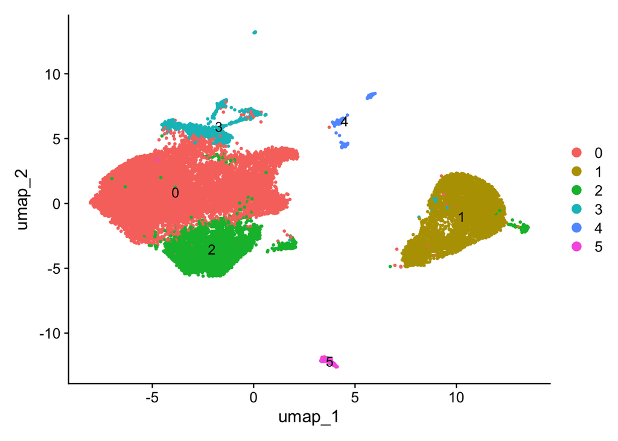

```r
Idents(seuratInfExpDH) <- seuratInfExpDH$RNA_snn_res.0.1
DimPlot(seuratInfExpDH, reduction = "umap", pt.size = 0.5, label = TRUE)
```

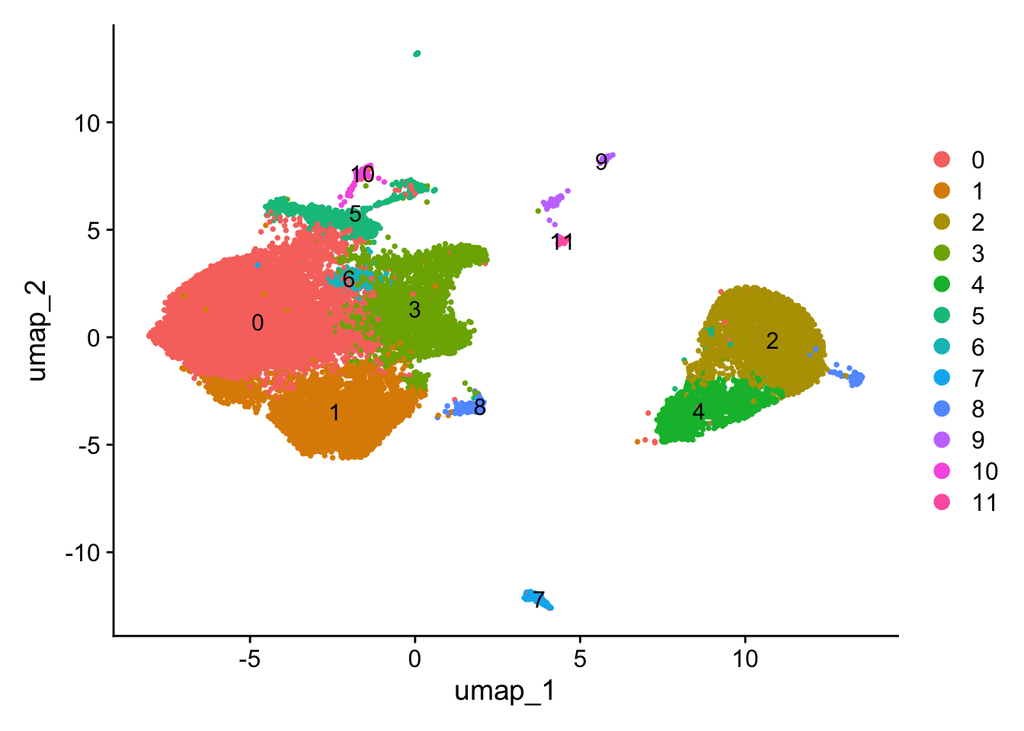

```r
Idents(seuratInfExpDH) <- seuratInfExpDH$RNA_snn_res.0.25
DimPlot(seuratInfExpDH, reduction = "umap", pt.size = 0.5, label = TRUE)
```

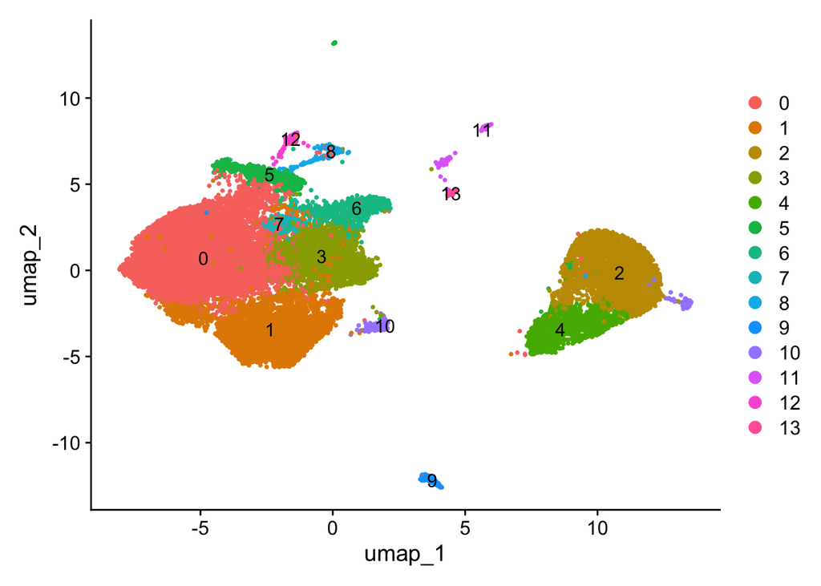

```r
Idents(seuratInfExpDH) <- seuratInfExpDH$RNA_snn_res.0.4
DimPlot(seuratInfExpDH, reduction = "umap", pt.size = 0.5, label = TRUE)
```

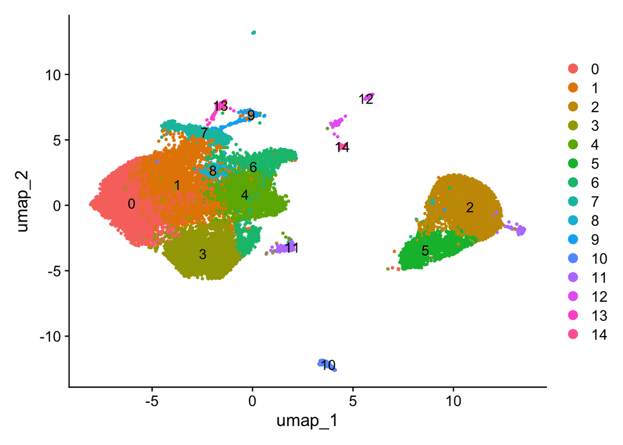

```r
Idents(seuratInfExpDH) <- seuratInfExpDH$RNA_snn_res.0.6
DimPlot(seuratInfExpDH, reduction = "umap", pt.size = 0.5, label = TRUE)
```

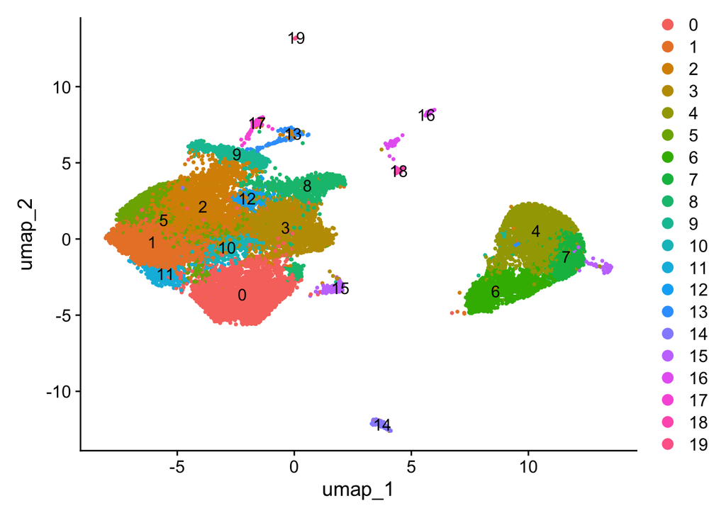

```r
Idents(seuratInfExpDH) <- seuratInfExpDH$RNA_snn_res.0.8
DimPlot(seuratInfExpDH, reduction = "umap", pt.size = 0.5, label = TRUE)
```

```r
#### cluster_name_Inf
seuratInfExpDH$clusterName <- "clusterName"
seuratInfExpDH$clusterName [which(seuratInfExpDH$RNA_snn_res.0.1 %in% "0" )] <- "Mph1"
seuratInfExpDH$clusterName [which(seuratInfExpDH$RNA_snn_res.0.1 %in% "1" )] <- "NK + Tcell"
seuratInfExpDH$clusterName [which(seuratInfExpDH$RNA_snn_res.0.1 %in% "2" )] <- "Mph2"
seuratInfExpDH$clusterName [which(seuratInfExpDH$RNA_snn_res.0.1 %in% "3" )] <- "Doublets"
seuratInfExpDH$clusterName [which(seuratInfExpDH$RNA_snn_res.0.1 %in% "4" )] <- "Bcell"
seuratInfExpDH$clusterName [which(seuratInfExpDH$RNA_snn_res.0.1 %in% "5" )] <- "Mastcell"


table(seuratInfExpDH$clusterName)
```

```
##
##      Bcell   Doublets   Mastcell       Mph1       Mph2 NK + Tcell
##        225       1095        210      11918       3464       4731
```

```r
table(seuratInfExpDH$RNA_snn_res.0.1)
```

```
##
##     0     1     2     3     4     5
## 11918  4731  3464  1095   225   210
```

```r
###order
Idents(seuratInfExpDH) <- seuratInfExpDH$clusterName
seuratInfExpDH$clusterName <- factor(seuratInfExpDH$clusterName, levels=c("Mph1", "Mph2", "NK + Tcell", "Mastcell", "Bcell", "Doublets"))
Idents(seuratInfExpDH) <- seuratInfExpDH$clusterName
table(seuratInfExpDH$clusterName)
```

```
##
##       Mph1       Mph2 NK + Tcell   Mastcell      Bcell   Doublets
##      11918       3464       4731        210        225       1095
```

```r
# set color for disease condition
coldiseaseCond <- c("#dfc27d","#BE3144")
names(coldiseaseCond) <- c("donorheart", "explant")

# set color for clusters
colclusterName <- c("#3CF","lightblue","#FCC80B","#D53E4F","#628395","grey")
names(colclusterName) <- c("Mph1", "Mph2", "NK + Tcell", "Mastcell", "Bcell", "Doublets")

#Combine slots
seuratInfExpDH$diseaseCond_clusterName <- paste0(seuratInfExpDH$diseaseCond, '_', seuratInfExpDH$clusterName)
table(seuratInfExpDH$diseaseCond_clusterName)
```

```
##
##      donorheart_Bcell   donorheart_Doublets   donorheart_Mastcell       donorheart_Mph1
##                    30                    25                    61                   853
##       donorheart_Mph2 donorheart_NK + Tcell         explant_Bcell      explant_Doublets
##                  3236                   523                   195                  1070
##      explant_Mastcell          explant_Mph1          explant_Mph2    explant_NK + Tcell
##                   149                 11065                   228                  4208
```

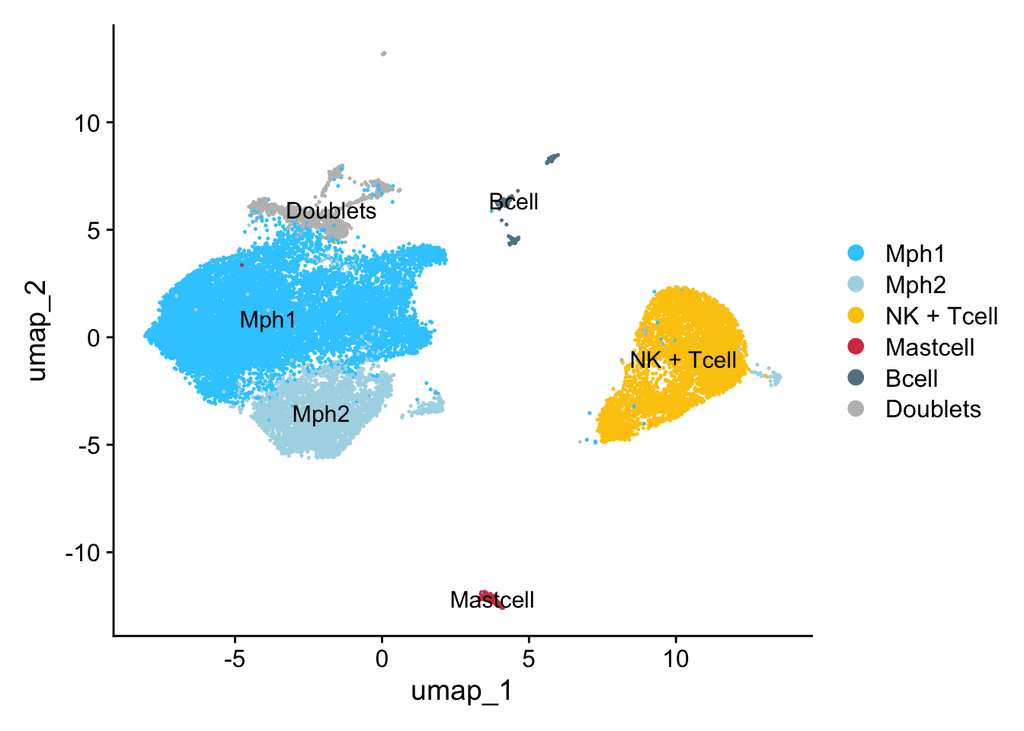

```r
#Plot UMAP
Idents(seuratInfExpDH) <- seuratInfExpDH$clusterName
DimPlot (seuratInfExpDH, reduction="umap", cols = colclusterName, pt.size = 0.1, label = TRUE)
```

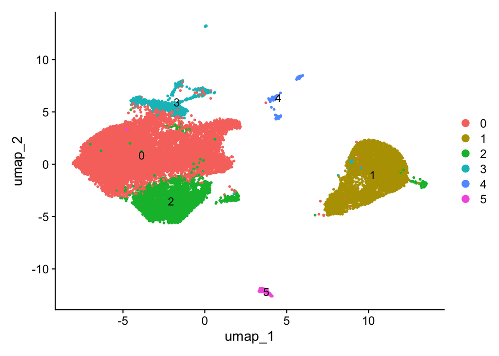

```r
Idents(seuratInfExpDH) <- seuratInfExpDH$RNA_snn_res.0.1
DimPlot(seuratInfExpDH, reduction = "umap", pt.size = 0.5, label = TRUE)
```

```r
##marker genes with resolution 0.1
#Idents(seuratInfExpDH) <- seuratInfExpDH$RNA_snn_res.0.1
#markerGenesInfExpDH_res.0.1<- FindAllMarkers(seuratInfExpDH, only.pos=T) %>%
#  dplyr::filter(p_val_adj < 0.01)

#save table
#write.table(markerGenesInfExpDH_res.0.1,
#            file= "/Users/immbio/Desktop/HumanHeartCarTrans2/analysis/markerGenesInfExpDH_RNA_snn_res.0.1",
#            sep="\t",
#            quote=F,
#            row.names=F,
#            col.names=T)

##marker genes with clusterName
Idents(seuratInfExpDH) <- seuratInfExpDH$clusterName
markerGenesInfExpDH_clusterName<- FindAllMarkers(seuratInfExpDH, only.pos=T) %>%
  dplyr::filter(p_val_adj < 0.01)

#save table
write.table(markerGenesInfExpDH_clusterName,
            file= "/Users/immbio/Desktop/HumanHeartCarTrans2/analysis/markerGenesInfExpDH_clusterNameInf",
            sep="\t",
            quote=F,
            row.names=F,
            col.names=T)
```

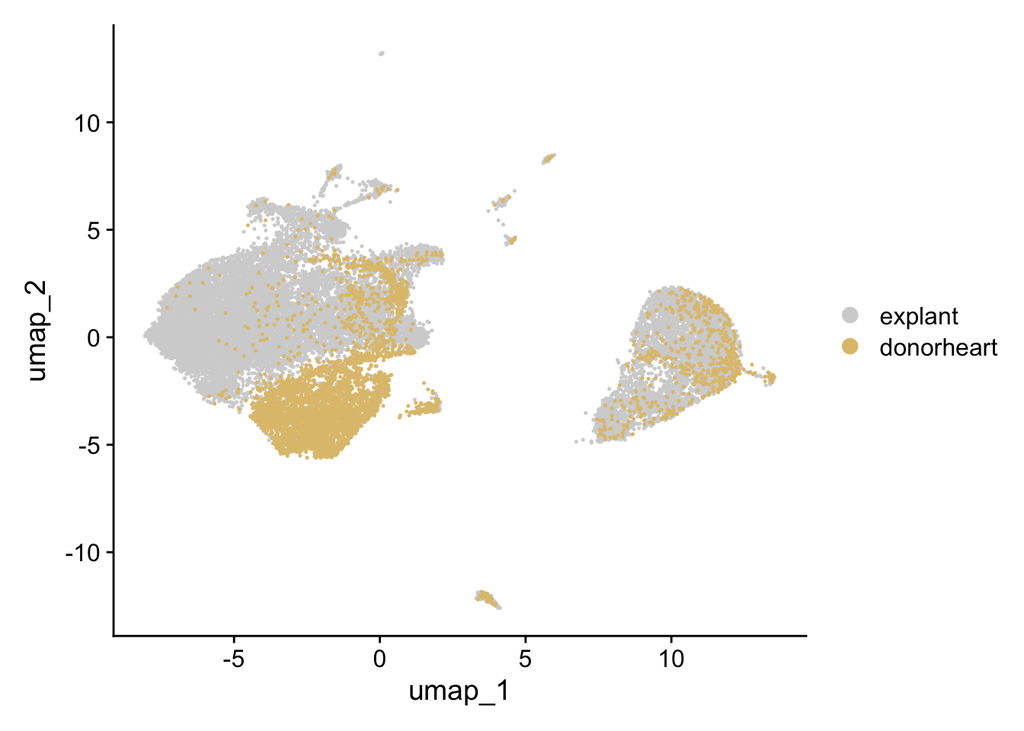

```r
Idents(seuratInfExpDH) <- seuratInfExpDH$diseaseCond
coldiseaseCond <- c("#dfc27d","lightgrey")
names(coldiseaseCond) <- c("donorheart", "explant")
DimPlot(seuratInfExpDH, reduction = "umap", pt.size = 0.1, cols = coldiseaseCond, order = "donorheart", raster = FALSE)
```

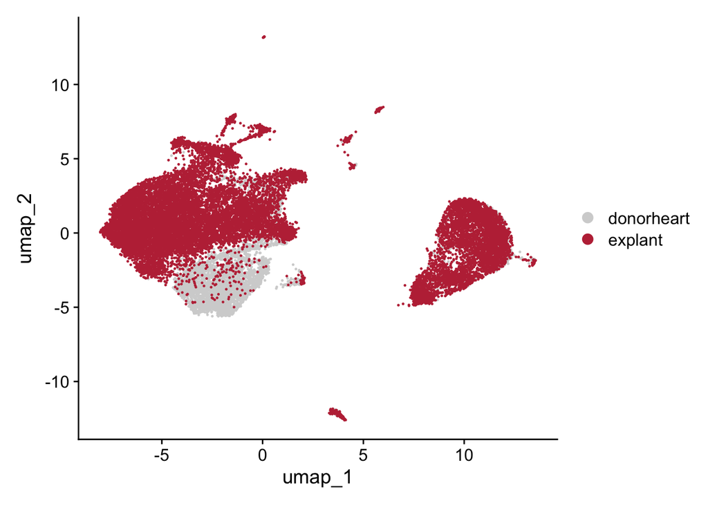

```r
Idents(seuratInfExpDH) <- seuratInfExpDH$diseaseCond
coldiseaseCond <- c("lightgrey","#BE3144")
names(coldiseaseCond) <- c("donorheart", "explant")
DimPlot(seuratInfExpDH, reduction = "umap", pt.size = 0.1, cols = coldiseaseCond, order = "explant", raster = FALSE)
```

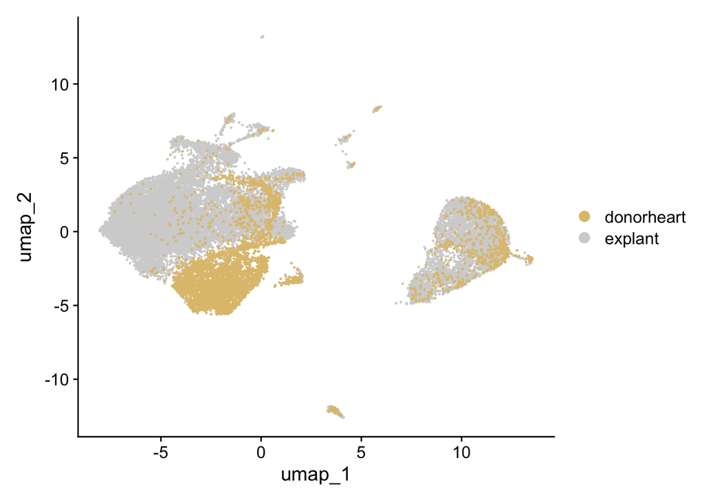

```r
Idents(seuratInfExpDH) <- seuratInfExpDH$diseaseCond
coldiseaseCond <- c("#dfc27d","lightgrey")
names(coldiseaseCond) <- c("donorheart", "explant")
DimPlot(seuratInfExpDH, reduction = "umap", pt.size = 0.1, cols = coldiseaseCond, raster = FALSE)
```

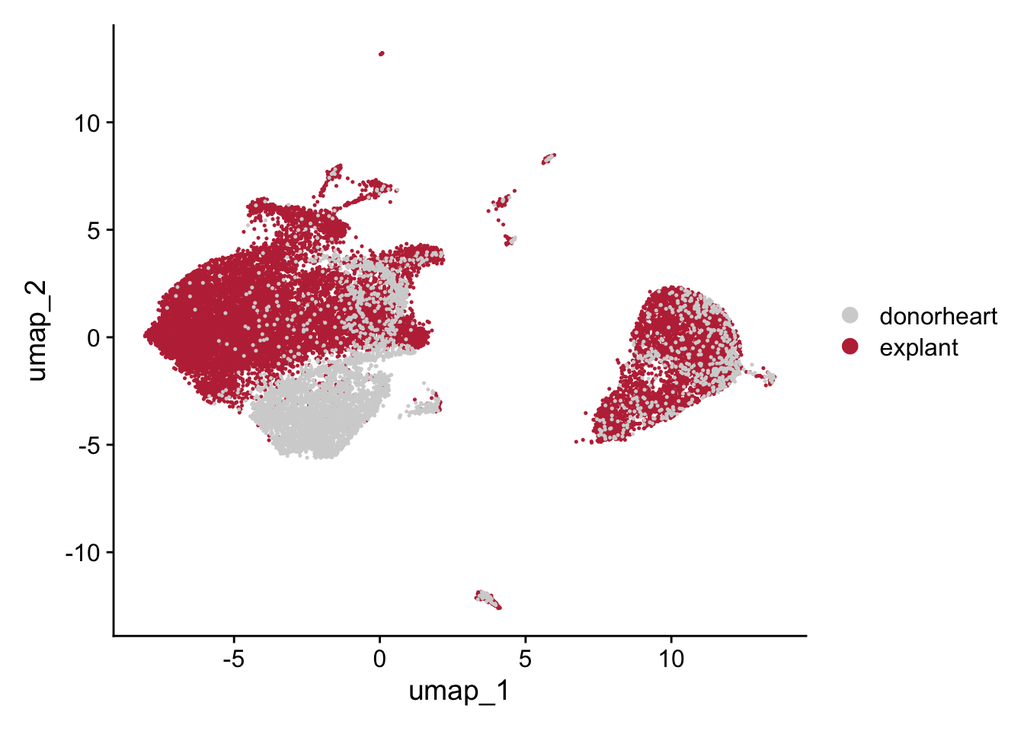

```r
Idents(seuratInfExpDH) <- seuratInfExpDH$diseaseCond
coldiseaseCond <- c("lightgrey","#BE3144")
names(coldiseaseCond) <- c("donorheart", "explant")
DimPlot(seuratInfExpDH, reduction = "umap", pt.size = 0.1, cols = coldiseaseCond, raster = FALSE)
```

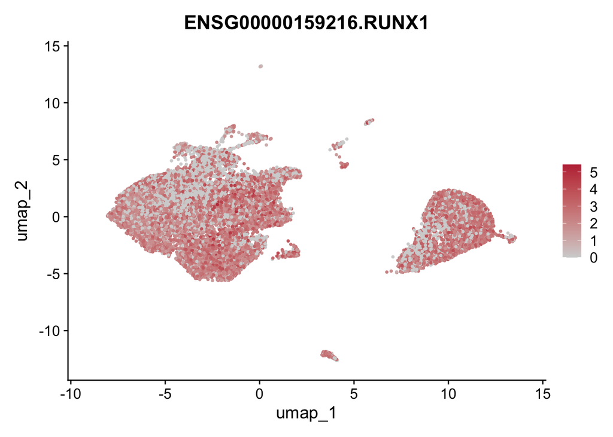

```r
# Screeening for clusters formed by cycling state
FeaturePlot(seuratInfExpDH, features = "ENSG00000159216.RUNX1", pt.size = 0.5, cols = c("lightgrey", "#BE3144"), raster = FALSE)
```

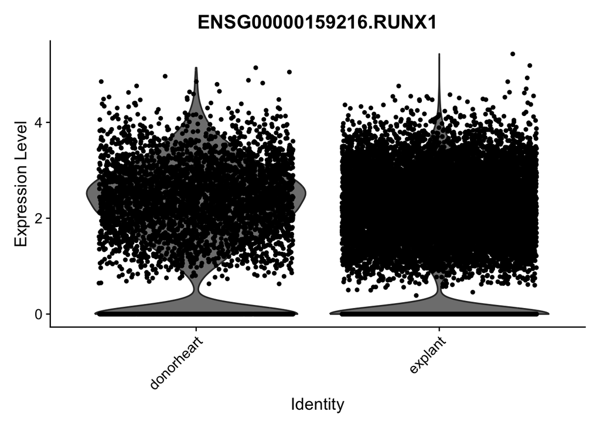

```r
VlnPlot( object = seuratInfExpDH, features = "ENSG00000159216.RUNX1", pt.size = 1, cols=colclusterName)
```

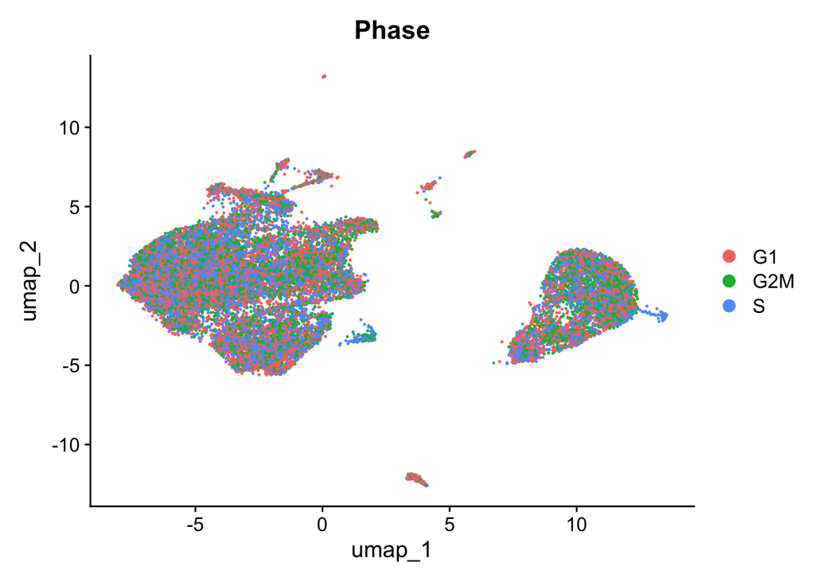

```r
cc.genes <- Seurat::cc.genes.updated.2019
s.genes <- c ("ENSG00000100297.MCM5", "ENSG00000132646.PCNA", "ENSG00000176890.TYMS", "ENSG00000168496.FEN1", "ENSG00000166508.MCM7", "ENSG00000104738.MCM4", "ENSG00000167325.RRM1", "ENSG00000076248.UNG", "ENSG00000131153.GINS2", "ENSG00000076003.MCM6", "ENSG00000144354.CDCA7", "ENSG00000143476.DTL", "ENSG00000198056.PRIM1", "ENSG00000276043.UHRF1", "ENSG00000151725.CENPU", "ENSG00000119969.HELLS", "ENSG00000049541.RFC2", "ENSG00000132780.NASP", "ENSG00000111247.RAD51AP1", "ENSG00000112312.GMNN", "ENSG00000092470.WDR76", "ENSG00000163950.SLBP", "ENSG00000175305.CCNE2",  "ENSG00000077514.POLD3",
"ENSG00000095002.MSH2", "ENSG00000156802.ATAD2", "ENSG00000051180.RAD51", "ENSG00000171848.RRM2", "ENSG00000093009.CDC45", "ENSG00000094804.CDC6", "ENSG00000174371.EXO1", "ENSG00000075131.TIPIN", "ENSG00000136982.DSCC1", "ENSG00000197299.BLM", "ENSG00000118412.CASP8AP2", "ENSG00000162607.USP1", "ENSG00000092853.CLSPN", "ENSG00000101868.POLA1", "ENSG00000159259.CHAF1B", "ENSG00000129173.E2F8" ) #not included POLR1B, UBR7, MRPL36
g2m.genes <- c ("ENSG00000164104.HMGB2", "ENSG00000170312.CDK1", "ENSG00000137804.NUSAP1", "ENSG00000175063.UBE2C", "ENSG00000089685.BIRC5", "ENSG00000088325.TPX2", "ENSG00000131747.TOP2A", "ENSG00000080986.NDC80", "ENSG00000123975.CKS2", "ENSG00000143228.NUF2", "ENSG00000173207.CKS1B", "ENSG00000148773.MKI67", "ENSG00000120802.TMPO", "ENSG00000117724.CENPF", "ENSG00000013810.TACC3", "ENSG00000129195.PIMREG", "ENSG00000113810.SMC4", "ENSG00000157456.CCNB2", "ENSG00000169607.CKAP2L", "ENSG00000136108.CKAP2", "ENSG00000178999.AURKB", "ENSG00000169679.BUB1", "ENSG00000138160.KIF11", "ENSG00000143401.ANP32E", "ENSG00000188229.TUBB4B", "ENSG00000075218.GTSE1", "ENSG00000138182.KIF20B", "ENSG00000123485.HJURP", "ENSG00000111665.CDCA3", "ENSG00000189159.JPT1", "ENSG00000117399.CDC20", "ENSG00000112742.TTK", "ENSG00000158402.CDC25C", "ENSG00000142945.KIF2C", "ENSG00000100401.RANGAP1", "ENSG00000010292.NCAPD2", "ENSG00000126787.DLGAP5", "ENSG00000184661.CDCA2", "ENSG00000134690.CDCA8", "ENSG00000114346.ECT2", "ENSG00000137807.KIF23", "ENSG00000072571.HMMR", "ENSG00000087586.AURKA", "ENSG00000134222.PSRC1", "ENSG00000011426.ANLN", "ENSG00000143815.LBR", "ENSG00000175216.CKAP5", "ENSG00000138778.CENPE", "ENSG00000102974.CTCF", "ENSG00000092140.G2E3", "ENSG00000139354.GAS2L3", "ENSG00000094916.CBX5", "ENSG00000115163.CENPA") #not included in dataset NEK2
seuratInfExpDH <- Seurat::CellCycleScoring(object = seuratInfExpDH, g2m.features = g2m.genes, s.features = s.genes)

Idents(seuratInfExpDH) <- seuratInfExpDH$clusterName
DimPlot(seuratInfExpDH, reduction = "umap", group.by = "Phase", pt.size = 0.1, raster=FALSE)
```

```r
orddiseaseCond <- c("donorheart", "explant")

###diseaseCond
datList <- NULL
for(con in unique(seuratInfExpDH$diseaseCond)){
  seuratSub <- subset(seuratInfExpDH, diseaseCond==con)
  print(dim(seuratSub))
  dat_con <- as.data.frame(table(seuratSub$clusterName)) %>%
  mutate(percent=Freq/ncol(seuratSub)) %>% mutate(diseaseCond=con)
  datList[[con]] <- dat_con
}
```

```
## [1] 45702 16915
## [1] 45702  4728
```

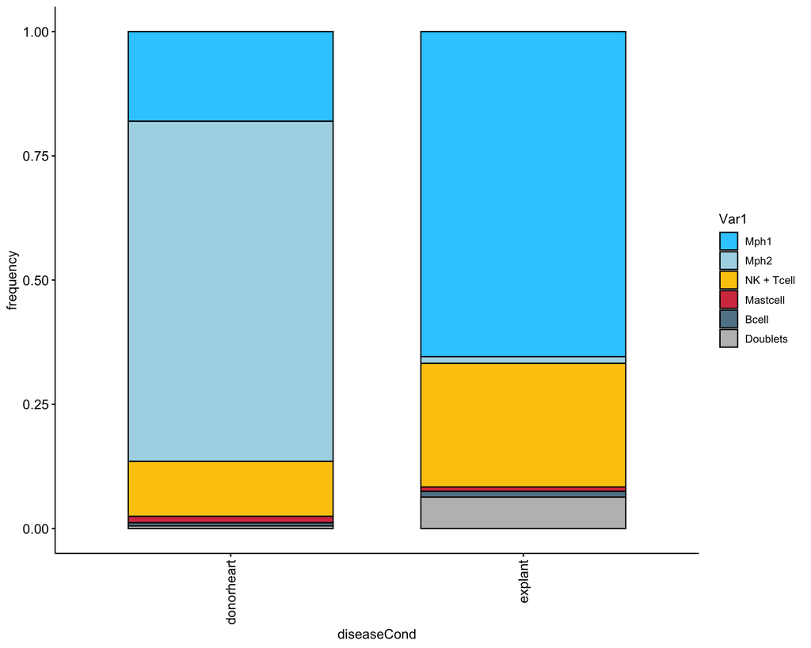

```r
dat_all <- do.call("rbind", datList)

## plot abundance
ggbarplot(dat_all, x= "diseaseCond", y= "percent", fill = "Var1", palette = colclusterName, legend = "right", legend.titel = "cluster", ylab = "frequency")  + theme(axis.text.x = element_text(angle = 90, vjust = 0.5, hjust=1)) + scale_x_discrete(limits=orddiseaseCond)
```

Reference: https://doi.org/10.1038/s41467-019-12464-3 CD4+ - Resting: CCR7, SELL, TCF7 (, KLT2, LEF1) Activation: IL2, TNF, IL4R Regulatory: FoxP3, IL2RA, CTLA4 Th1: INFy, Il2 Th2: IL-4, -13 Th17: IL-17A, KLRB1 (CD161)

CD8+ - T effector/resident memory: CCL5, GZMB, GZMK Resident memory: CXCR6, ITGA1 Activated TEM/TRM: IFNG, CCL4, CCL3 Terminally differentiated effector cells: PRF1, NKG7

T cell activation/proliferation: IL2, LIF, NME1, CXCR6, Phgdh Cell division: CENPV, G0S2, ORC6 IFN response: IFIT3, IFIT2 STAT1, MX1, IRF7, JAK2 Cytotoxicity: GNLY, GZMK Effector/memory differentiation: ZEB2, EOMES, ZNF683

DOI: 10.1038/s41590-020-0791-5. Early differentiating memory T cells: CCR7, LEF1, SELL (encodes CD62L), FOXP1 Effector transpricts - identification of effector memory cells: GZMK, GZMB, IFNG, CCL4, CCL5 Activated TStem cells - BACH2, ID3, IL2 and SATB1 Reminiscent terminal effector T cells: BZMB, GNLY, ZEB2, GZMA Exhausted-like CD8+ T cell progenitors: GZMK, PD-1, TIGIT - activated exhausted Cells additionally: TOX, PDCD1, MAF, CXCL13 T cell memory: LEF1, SELL, CCR7, BACH2, SATB1

NK cells: https://doi.org/10.1038/s41590-024-01883-0 NCAM1 (CD56), S100A4, FCGR3B, FCGR3A

Mastcells: KIT, TSAB1, HPGDS, SLC18A2, GATA2/RAB44/ENPP3/BTK/ADGRE2, NDST2

Macrophages: CD68, CD300E Activation markers: GLUT1, NOS2, CXCL9, CXCL10, MT2A, CXCL11, CCL8, CD274

MCH II: HLA-DR + HLA-DQ https://panglaodb.se/markers.html?cell_type=%27Dendritic%20cells%27 Dendritic cells: ITGAX (CD11c), HLA-DRB1, ZBTB46, CD83, S100A9

```r
seuratInfExpDH$clusterName <- factor(seuratInfExpDH$clusterName, levels=c("Mph1", "Mph2", "NK + Tcell", "Mastcell", "Bcell", "Doublets"))
Idents(seuratInfExpDH) <-seuratInfExpDH$clusterName
levels(seuratInfExpDH)
```

```
## [1] "Mph1"       "Mph2"       "NK + Tcell" "Mastcell"   "Bcell"      "Doublets"
```

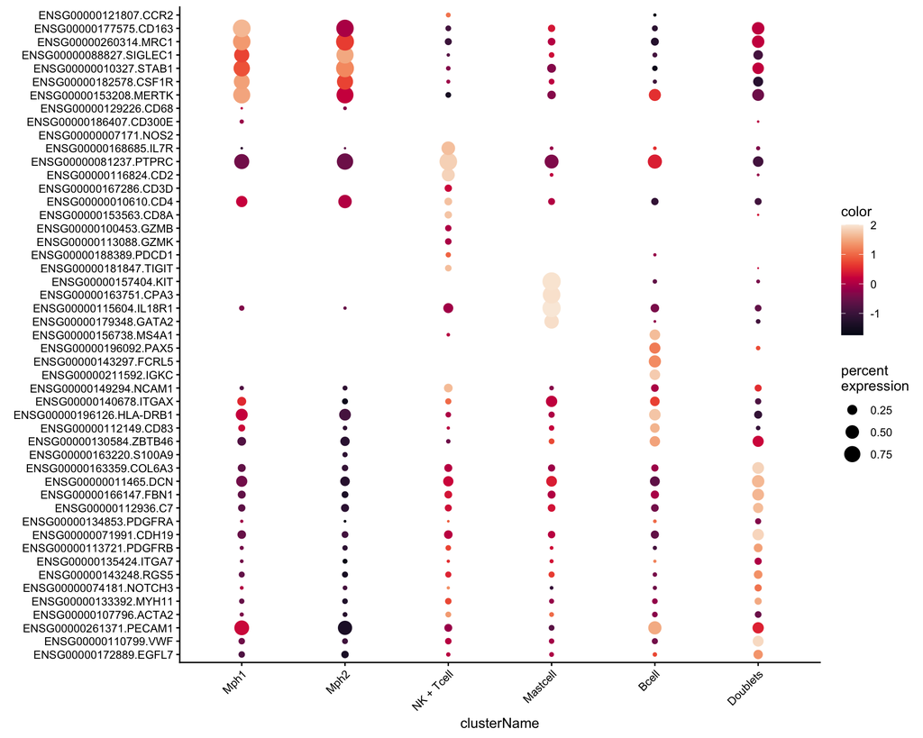

```r
genes <- data.frame(gene=rownames(seuratInfExpDH)) %>%
  mutate(geneID=gsub("^.*\\.", "", gene))

# Create selGenes with geneID vector, join, and filter
selGenes <- data.frame(geneID = rev(c("CCR2", "CD163", "MRC1", "SIGLEC1", "STAB1", "CSF1R", "MERTK", "CD68", "CD300E", "NOS2", "IL7R", "PTPRC", "CD2","CD3D", "CD4", "CD8A", "GZMB", "GZMK", "PDCD1", "TIGIT", "KIT", "CPA3", "IL18R1", "GATA2", "MS4A1", "PAX5", "FCRL5","IGKC", "NCAM1", "ITGAX", "HLA-DRB1", "CD83", "ZBTB46", "S100A9", "COL6A3", "DCN",  "FBN1", "C7", "PDGFRA", "CDH19", "PDGFRB","ITGA7","RGS5", "NOTCH3", "MYH11", "ACTA2","PECAM1", "VWF", "EGFL7"))) %>%
  left_join(., genes, by = "geneID") %>%
  filter(gene != "ENSG00000232995.RGS5")

dittoSeq::dittoDotPlot(seuratInfExpDH, vars = selGenes$gene, group.by = "clusterName") + RotatedAxis() + coord_flip() + scale_color_viridis(option= "F")
```

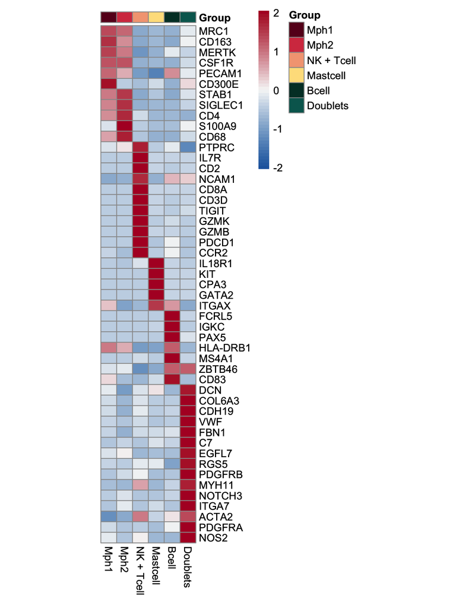

```r
Idents(seuratInfExpDH) <- seuratInfExpDH$clusterName
ImmunoLogic::avgHeatmap(seuratInfExpDH, selGenes= selGenes)
```

```r
#View(markerGenesInfExpDH_res.0.25[markerGenesInfExpDH_res.0.25$cluster ==  10,])
```

# Feature plots

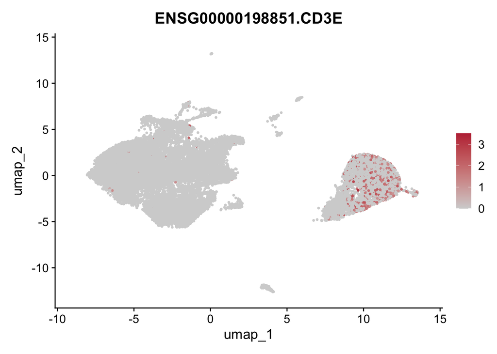

```r
FeaturePlot(seuratInfExpDH, features = "ENSG00000198851.CD3E", pt.size = 0.5, cols = c("lightgrey", "#BE3144"))
```

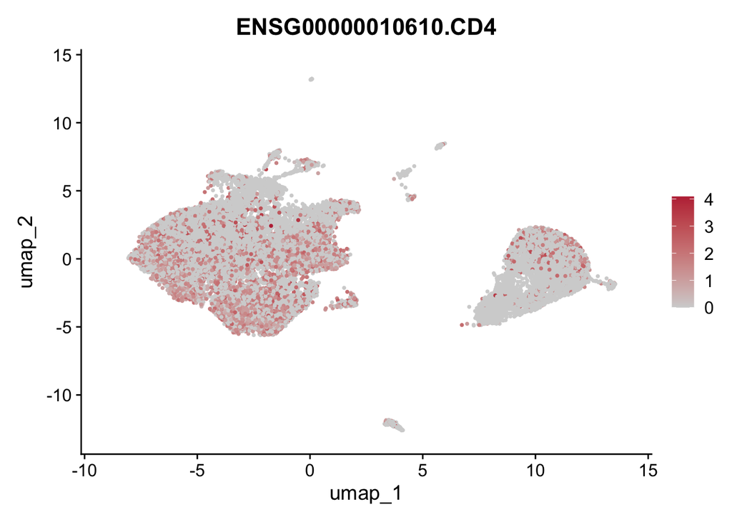

```r
FeaturePlot(seuratInfExpDH, features = "ENSG00000010610.CD4", pt.size = 0.5, cols = c("lightgrey", "#BE3144"))
```

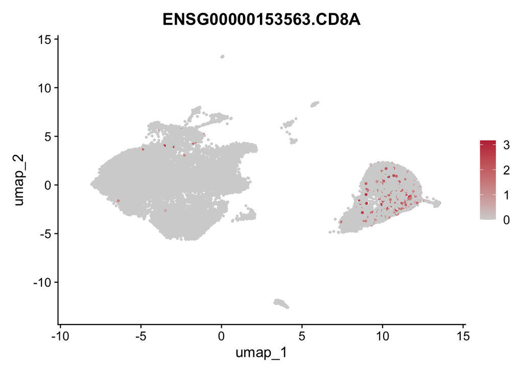

```r
#Cytotoxic T cells
FeaturePlot(seuratInfExpDH, features = "ENSG00000153563.CD8A", pt.size = 0.5, cols = c("lightgrey", "#BE3144"))
```

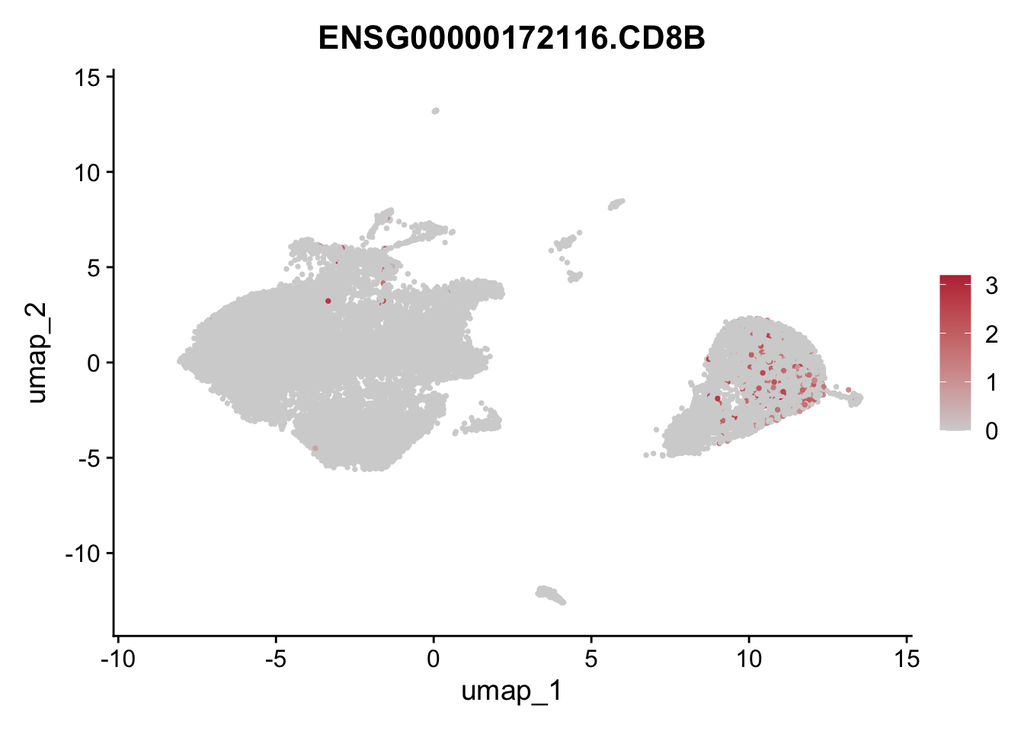

```r
FeaturePlot(seuratInfExpDH, features = "ENSG00000172116.CD8B", pt.size = 0.5, cols = c("lightgrey", "#BE3144"))
```

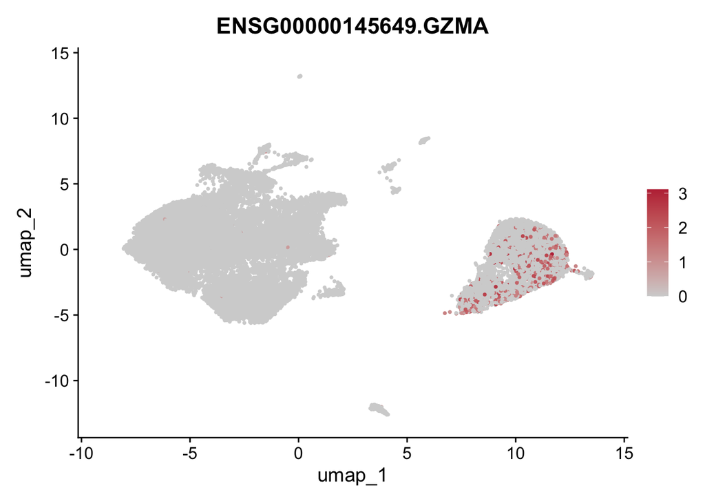

```r
FeaturePlot(seuratInfExpDH, features = "ENSG00000145649.GZMA", pt.size = 0.5, cols = c("lightgrey", "#BE3144"))
```

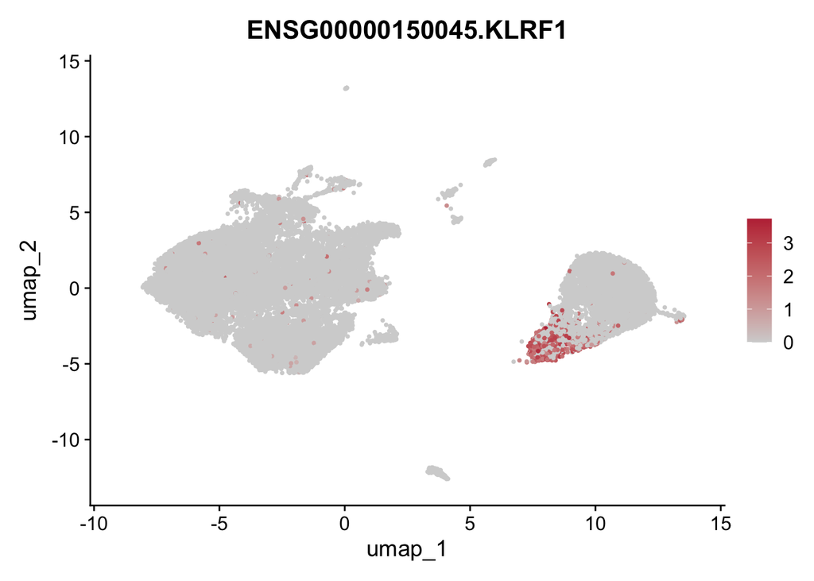

```r
FeaturePlot(seuratInfExpDH, features = "ENSG00000150045.KLRF1", pt.size = 0.5, cols = c("lightgrey", "#BE3144"))
```

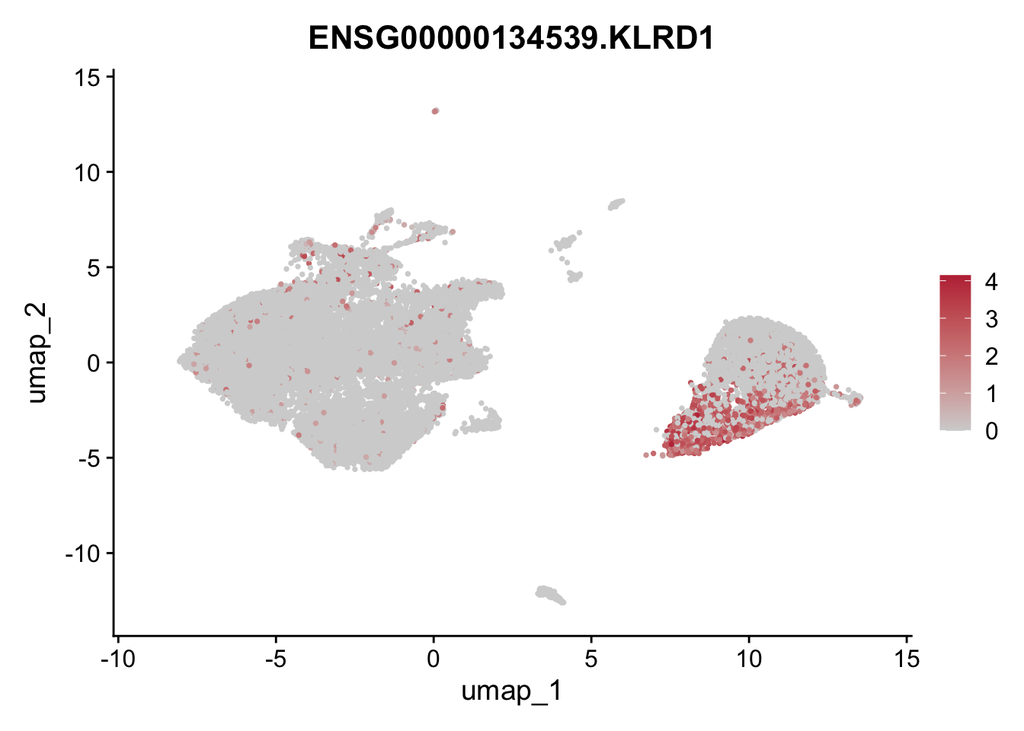

```r
FeaturePlot(seuratInfExpDH, features = "ENSG00000134539.KLRD1", pt.size = 0.5, cols = c("lightgrey", "#BE3144"))
```

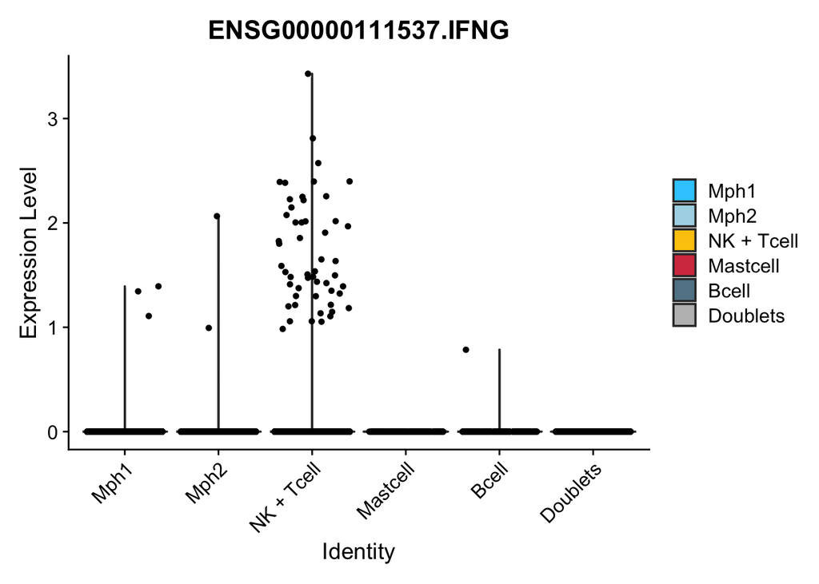

```r
VlnPlot(object = seuratInfExpDH, features = "ENSG00000111537.IFNG", pt.size = 1, cols=colclusterName)
```

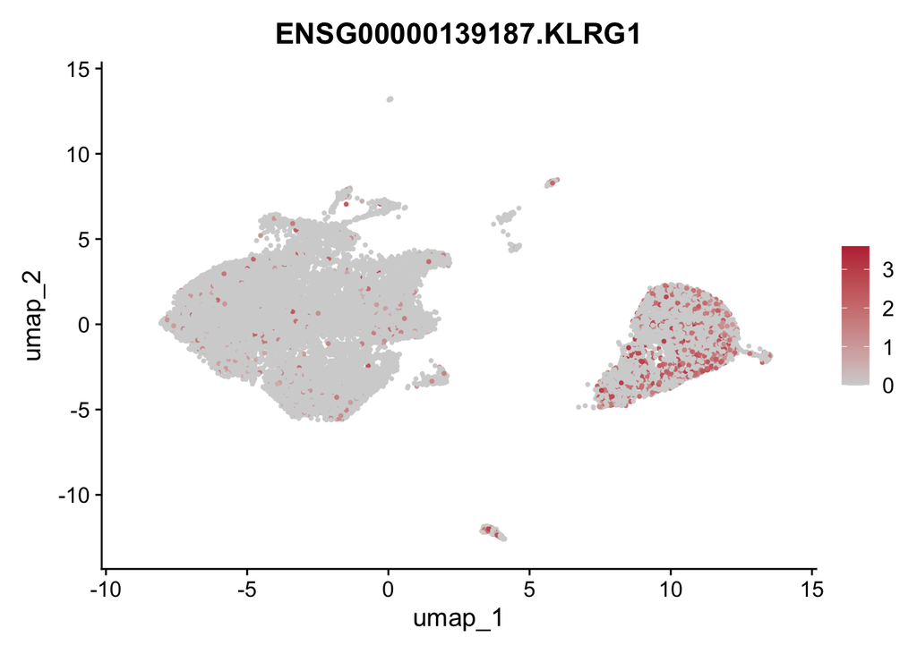

```r
#NK cells
FeaturePlot(seuratInfExpDH, features = "ENSG00000139187.KLRG1", pt.size = 0.5, cols = c("lightgrey", "#BE3144"))
```

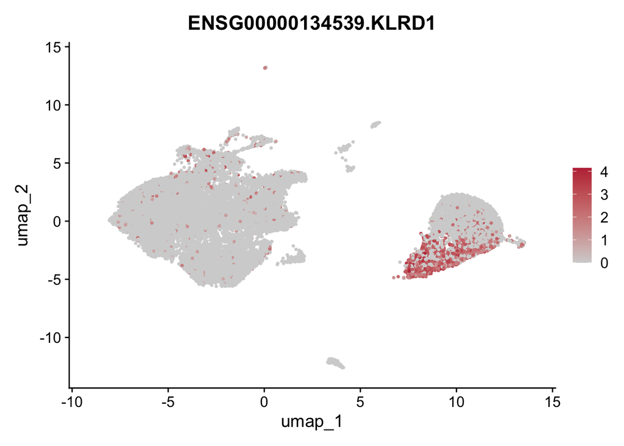

```r
FeaturePlot(seuratInfExpDH, features = "ENSG00000134539.KLRD1", pt.size = 0.5, cols = c("lightgrey", "#BE3144"))
```

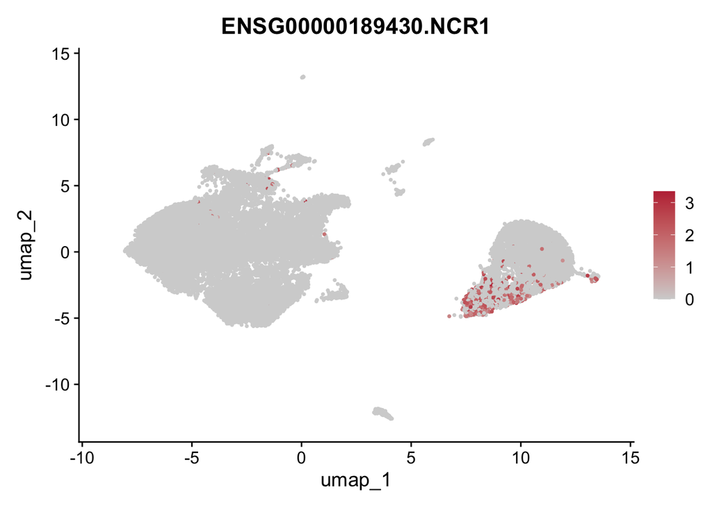

```r
FeaturePlot(seuratInfExpDH, features = "ENSG00000189430.NCR1", pt.size = 0.5, cols = c("lightgrey", "#BE3144"))
```

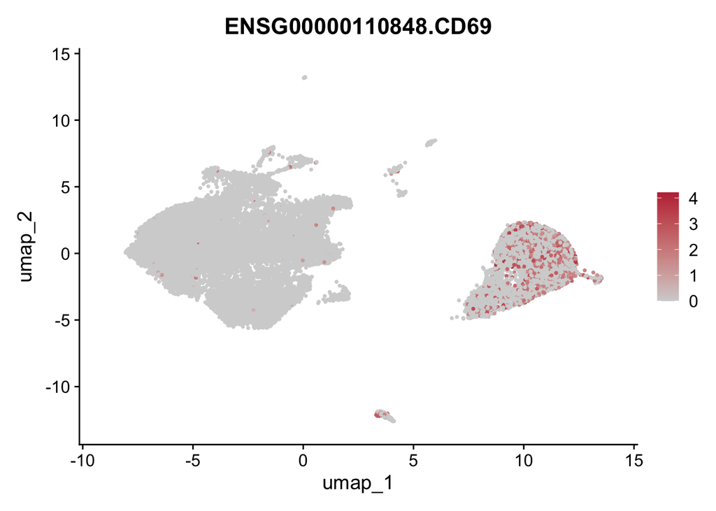

```r
FeaturePlot(seuratInfExpDH, features = "ENSG00000110848.CD69", pt.size = 0.5, cols = c("lightgrey", "#BE3144"))
```